# INFSCI 2595 Fall 2023 Homework: 04

Assigned September 20, 2023; Due: September 27, 2023

SOLUTION GUIDE

Submission time: September 27, 2023 at 11:00PM EST

#### Collaborators

Include the names of your collaborators here.

## Overview

This assignment is focused on the mathematics of likelihoods, priors, and posteriors. You will work with binomially distributed data in this assignment. You must perform calculations in R using for-loops, functions, and visualize your results using `ggplot2`. You must also perform derivations and type your expressions in LaTeX within equation blocks.

### IMPORTANT!!!

Certain code chunks are created for you. Each code chunk has `eval=FALSE` set in the chunk options. You **MUST** change it to be `eval=TRUE` in order for the code chunks to be evaluated when rendering the document.

You are free to add more code chunks if you would like.

## Load packages

You will ONLY use functions from the `tidyverse` in this assignment.

```r
library(tidyverse)
```

## Problem 01

Baseball has a rich history of quantitative analysis, even before the rise of advanced analytics techniques. Batting averages, slugging percentages, and other metrics have been used to evaluate player performance for over one hundred years. The batting average, BA, is calculated using the number of at bats, AB, and the successful number of hits, H. The batting average measures the proportion of at bats that a player successfully gets a hit. You can think of the number of hits as the number of **events** and the number of at bats as the number of **trials**.

You will work with a sequence of at bats of a real Major League Baseball (MLB) player. This sequence is a small sample from the 2022 MLB season. You are not told who this player is so that way you cannot know for certain if the player is a “good” or “bad” hitter! All you are provided with is the small sample size provided below.

The code chunk below populates the data using the encoding and format discussed in lecture. Each observation (element) of the vector `x` corresponds to an individual at bat. The result, hit or out, is recorded as 1 for hit (**event**) and 0 for out (**non-event**).

```r
x <- c(0, 0, 0, 0,
       0, 1, 1, 0,
       1, 0, 0, 0,
       0, 1, 1, 0, 1,
       1, 0, 0, 1,
       0, 0, 1, 0,
       1, 1, 1, 0, 0,
       0, 0, 1, 1)
```

### 1a)

**Calculate the average of the `x` vector.**

**Display the result to the screen.**

#### SOLUTION

We can answer this a few ways. First, we can calculate the sum and divide by the length.

```r
sum( x ) / length( x )
```

```
## [1] 0.4117647
```

Or we can call the `mean()` function directly!

```r
mean( x )
```

```
## [1] 0.4117647
```

Or we could use the forward pipe operator to apply the `mean()` function.

```r
x %>% mean()
```

```
## [1] 0.4117647
```

### 1b)

The player’s batting results, hit or out, is a **binary outcome** which we will assume is a **Bernoulli** random variable. The likelihood function for each at bat (observation) is therefore the Bernoulli distribution. We will also assume the at bats are **independent**. The Bernoulli distribution consists of a single unknown parameter, $\mu$, the **event probability**. In the context of this application, the event probability represents the probability the player gets a hit.

Having collected the player’s data, you are tasked with estimating the player’s hit probability. In lecture, we derived the Maximum Likelihood Estimate (MLE) for $\mu$.

**Without going through any mathematical derivations, what is the MLE for this player’s hit probability, based on the data provided?**

#### SOLUTION

The MLE of a sequence of independent Bernoulli trials corresponds to the basic definition of probability! The MLE is the number of events divided by the number of trails!

The number of events can be calculated by summing the observations of `x`. The number of trials can be found from the length of the `x` vector.

```r
sum( x ) / length( x )
```

```
## [1] 0.4117647
```

The sum divided by the length is just the average! So alternatively, we could use the `mean()` function!

```r
mean( x )
```

```
## [1] 0.4117647
```

### 1c)

**How does your result to 1a) compare to the result in 1b)?**

#### SOLUTION

They are the same! The expected value (mean) of the Bernoulli distribution corresponds to the MLE for the event probability!

### 1d)

Let’s now dive into the Bernoulli distribution in greater detail.

**Write the natural log of the Bernoulli distribution for a single at bat (observation) $x_n$ given the hit (event) probability, $\mu$.**

**You MUST include at least several steps which simplify the expression using the properties of the natural log to receive full credit.**

#### SOLUTION

The Bernoulli likelihood of the single observation, $x_n$, given the event probability $\mu$ is shown below.

$$p \left( x_n \mid \mu \right) = \mathrm{Bernoulli}\left(x_n \mid \mu
\right) = \mu^{x_n} \left( 1 - \mu \right)^{1-x_n}$$

The natural log of the Bernoulli likelihood is straightforward to write down:

$$\log \left( p \left( x_n \mid \mu \right) \right) = \log \left(
\mu^{x_n} \left( 1 - \mu \right)^{1-x_n} \right)$$

However, let’s simplify the above expression by making use of log arithmetic. With logs, products become additions of the log of the terms:

$$\log \left( \mu^{x_n} \left( 1 - \mu \right)^{1-x_n} \right) = \log
\left( \mu^{x_n} \right) + \log \left( \left( 1 - \mu \right)^{1-x_n}
\right)$$

Each term within the log can be simplified further because exponents become multipliers when we work with logs:

$$\log \left( \mu^{x_n} \right) + \log \left( \left( 1 - \mu
\right)^{1-x_n} \right) = x_n \log \left( \mu \right) + \left(1 - x_n
\right) \log \left( 1 - \mu \right)$$

The log of the Bernoulli likelihood is therefore a rather simple expression after we have made use of the properties of logs!

$$\log \left( \mathrm{Bernoulli}\left(x_n \mid \mu \right) \right) = x_n
\log \left( \mu \right) + \left(1 - x_n \right) \log \left( 1 - \mu
\right)$$

### 1e)

The `log_bernoulli_pmf()` function is started for you in the code chunk below. It consists of two input arguments, `xobs`, and `prob`. The `xobs` argument is a numeric vector of observations of a binary variable encoded as 0 and 1. The `prob` argument is the event probability.

**Complete the code chunk below by correctly calculating the log of the Bernoulli PMF. The function must return a numeric vector the same length as the `xobs` argument.**

#### SOLUTION

```r
log_bernoulli_pmf <- function(xobs, prob)
{
  xobs * log( prob ) + (1 - xobs) * log( 1 - prob )
}
```

### 1f)

Let’s check the operation of your `log_bernoulli_pmf()` function.

**Use separate function calls to the `log_bernoulli_pmf()` function to calculate the values associated with the 1st, 2nd, 3rd, 4th, 5th, and 6th observations of the `x` vector. Therefore, you must provide a single `x` observation to the function and do so 6 times.**

**Use an event probability equal to 0.250 in each function call.**

**Display the results to the screen.**

#### SOLUTION

We can index a vector with the `[]`. Thus, the first element in `x` is:

```r
x[1]
```

```
## [1] 0
```

The 2nd element in `x` is:

```r
x[2]
```

```
## [1] 0
```

We need to call the function 6 times where the `xobs` argument is assigned to the 6 different elements of `x`. The first 5 function calls are executed below.

```r
log_bernoulli_pmf(x[1], prob = 0.25)
```

```
## [1] -0.2876821
```

```r
log_bernoulli_pmf(x[2], prob = 0.25)
```

```
## [1] -0.2876821
```

```r
log_bernoulli_pmf(x[3], prob = 0.25)
```

```
## [1] -0.2876821
```

```r
log_bernoulli_pmf(x[4], prob = 0.25)
```

```
## [1] -0.2876821
```

```r
log_bernoulli_pmf(x[5], prob = 0.25)
```

```
## [1] -0.2876821
```

Notice that all 5 values are the same! That is because all 5 elements of `x` are the same!

As an aside, we could have used the forward pipe operator to execute the function call. The code chunk below demonstrates that approach.

```r
x[5] %>% log_bernoulli_pmf(prob = 0.25)
```

```
## [1] -0.2876821
```

You might be wondering what is the point of this exercise? The point is to highlight that the observation value (the value of `x`) dictates the value of the log-likelihood. The log-likelihood values were the same for the first 5 elements because the observation values were the same! A different observation value will change the log-likelihood. The 6th observation has a value of 1, as shown below:

```r
x[6]
```

```
## [1] 1
```

The log-likelihood is different for the 6th observation compared to the previous 5:

```r
x[6] %>% log_bernoulli_pmf(prob = 0.25)
```

```
## [1] -1.386294
```

Please remember that we calculated the **log** of the Bernoulli PMF. We can recover the **probability** by undoing the log-transformation via the `exp()` function. For example, the probability of the non-event, such as with `x[1]`, is:

```r
x[1] %>% log_bernoulli_pmf(prob = 0.25) %>% exp()
```

```
## [1] 0.75
```

Likewise the probability of the event is the `exp()` of the `x = 1`, as with `x[6]`:

```r
x[6] %>% log_bernoulli_pmf(prob = 0.25) %>% exp()
```

```
## [1] 0.25
```

### 1g)

The previous question focused on testing the function for a single observation. Let’s now check the function works when multiple observations are provided.

**Pass the first 6 elements of the `x` vector into the `log_bernoulli_pmf()` function. You must still use an event probability equal to 0.250.**

**Display the result to the screen.**

**What is the length of the returned result? How do the values compare to the previous question where you called the function separately for each observation?**

#### SOLUTION

We can slice a vector to return more than a single element at a time. The first six elements of `x` are sliced and displayed below:

```r
x[1:6]
```

```
## [1] 0 0 0 0 0 1
```

The `log_bernoulli_pmf()` function accepts a vector for the `xobs` argument. We can therefore provide the first 6 elements of `x` via the slice, `x[1:6]`, to `log_bernoulli_pmf()`. As shown below, a single value is NOT returned! Instead we get a vector with the same length that we provided! The result therefore has 6 values!

```r
log_bernoulli_pmf( x[1:6], prob = 0.25 )
```

```
## [1] -0.2876821 -0.2876821 -0.2876821 -0.2876821 -0.2876821 -1.3862944
```

The first element of the above result is the same as the result when we called the function with `x[1]` alone. The first 5 values are the same because the first 5 elements of `x` are all zero. The last value, the 6th value, is different from the other 5 because the 6th element of `x` is NOT zero!

We could also use the forward pipe operator to answer this question.

```r
x[1:6] %>% log_bernoulli_pmf(prob = 0.25)
```

```
## [1] -0.2876821 -0.2876821 -0.2876821 -0.2876821 -0.2876821 -1.3862944
```

## Problem 02

Now that you have practiced calculating the log Bernoulli PMF, let’s consider the **joint distribution** of all observations. Remember that the joint distribution is the **likelihood function** for this application. It corresponds to the probability of the exact sequence of observed data given the assumptions. The likelihood of all $N$ observations is written in vector notation for you in the equation block below:

$$p \left(x_1, x_2, ... , x_n, , ..., x_{N-1}, x_N \mid \mu \right) = p
\left( \mathbf{x} \mid \mu \right)$$

### 2a)

**Write the expression for the “complete” log-likelihood assuming the observations are independent.**

#### SOLUTION

The “complete” log-likelihood is the sum of the $N$ conditionally independent log-likelihoods:

$$\log \left( p\left( \mathbf{x} \mid \mu \right) \right) = \sum_{n=1}^{N}
\left( \log \left( \mathrm{Bernoulli} \left(x_n \mid \mu \right) \right)
\right)$$

Let’s substitute the expression for the $n$-th observation’s log-Bernoulli that we derived previously:

$$\log \left( p\left( \mathbf{x} \mid \mu \right) \right) = \sum_{n=1}^{N}
\left( x_n \log \left( \mu \right) + \left(1 - x_n \right) \log \left( 1
- \mu \right) \right)$$

There are two components or pieces within the summation series. Summation is a linear operator and so we can break up or partition the summation series to each term:

$$\log \left( p\left( \mathbf{x} \mid \mu \right) \right) = \sum_{n=1}^{N}
\left( x_n \log \left( \mu \right) \right) + \sum_{n=1}^{N} \left(
\left(1 - x_n \right) \log \left( 1 - \mu \right) \right)$$

The log of the event probability and the log of one minus the event probability are constant values. The constants can be “pulled” in front of the summation series:

$$\log \left( p\left( \mathbf{x} \mid \mu \right) \right) =
\log\left(\mu\right) \sum_{n=1}^{N} \left( x_n \right) + \log\left(1 -
\mu\right) \sum_{n=1}^{N} \left(1 - x_n \right)$$

As discussed in lecture the summation of the $\mathbf{x}$ vector is a summation of binary values! The individual $x_n$ observations are either zero (non-event) or one (event). Thus, the summation of $x_n$ from $n=1$ to $n=N$ is the number of events! In the context, of the current problem, the number of events is the number of hits, $H$:

$$\sum_{n=1}^{N} \left( x_n \right) = H$$

The summation of $1 - x_n$ from $n=1$ through $n=N$ is the number of non-events or the number of trials (at bats, $AB$) minus the number of events (hits, $H$):

$$\sum_{n=1}^{N} \left(1 - x_n \right) = AB - H$$

The log-likelihood takes a relatively simple form by substituting the above two expressions for the two summation series:

$$\log \left( p\left( \mathbf{x} \mid \mu \right) \right) =
\log\left(\mu\right) \times H + \log\left(1 - \mu\right) \times \left(
AB - H \right)$$

You may receive full credit for this problem by writing the “complete” log-likelihood as the summation of the independent Bernoulli likelihoods. You had to at least write the expression of the Bernoulli PMF and not just type “Bernoulli” to receive full credit.

### 2b)

**Calculate the “complete” log-likelihood for all observations in `x`. You must continue to use an event probability of 0.25.**

**Display the result to the screen.**

#### SOLUTION

The “complete” log-likelihood assuming independent observations is the SUM of the $N$ individual log-likelihoods. We must therefore provide the `x` vector as input to `log_bernoulli_pmf()` and “wrap” the `log_bernoulli_pmf()` function with the `sum()` function.

```r
sum( log_bernoulli_pmf(xobs = x, prob = 0.25) )
```

```
## [1] -25.16176
```

Alternatively, we can use the forward pipe to accomplish the same task!

```r
x %>% log_bernoulli_pmf(prob = 0.25) %>% sum()
```

```
## [1] -25.16176
```

We could have calculated this result directly because the “complete” log-likelihood has such a simple functional form. The “complete” log-likelihood is simply the log of probability of the event times the number of events plus the log of the probability of the non-event times the number of non-events:

```r
log( 0.25 ) * sum(x) + log( 1 - 0.25 ) * sum( 1 - x )
```

```
## [1] -25.16176
```

This problem was intended for applying the `sum()` function to the `log_bernoulli_pmf()` function created previously. However, you may also receive full credit by calculating directly, as shown in the above code chunk.

### 2c)

You might be wondering, why are you using probabilities of 0.25 when you already calculated the MLE at the beginning of the assignment? We derived the MLE in lecture, but you will graphically find the MLE in this assignment. You must therefore calculate the log-likelihood for many candidate event probability values, graph the results, and visually identify the probability that maximizes the likelihood.

You will do this to reinforce optimization concepts such as why the MLE corresponds to the first derivative equal to zero. This exercise will also introduce visualizing curvature, an important concept we will discuss in greater depth later. Thus, the next few questions are laying the foundation for more complicated optimization problems such as training neural networks.

You must call the `log_bernoulli_pmf()` function for many potential probability **candidate values**. You will use for-loops to accomplish the iteration procedure. A for-loop is not the most efficient approach to accomplishing this task. We will see more efficient methods soon. For now, the basic for-loop will demonstrate the key concepts.

However, we need to setup the book keeping before we can iterate. We need the candidate probability values defined before anything else can happen.

**Define a candidate grid of event probability values as a numeric vector using the `seq()` function. Specify the `from` argument to be 0.025 and the `to` argument to be `0.975`. Create the vector such that 251 evenly spaced values are between the bounds.**

**Assign the vector the `mu_grid` object.**

#### SOLUTION

```r
mu_grid <- seq(0.025, 0.975, length.out = 251)
```

### 2d)

The basic structure of a for-loop in `R` is shown in the code chunk below. This simple for-loop simply prints the value of the *iterating variable* `n` to the screen. The `for` keyword is used to begin the for-loop. We must specify the iterating variable and the **sequence** the iterating variable is **in** within parentheses, `()`. The sequence in the example below is a vector starting at 1 and ending at 4.

```r
for( n in 1:4 ){
  print( n )
}
```

```
## [1] 1
## [1] 2
## [1] 3
## [1] 4
```

When we wish to calculate values and store them as elements within a larger object within a for-loop, it is best to first *initialize* the object with the appropriate size. This variable `example_vector` is initialized with `NA` (missing values) using the `rep()` function 10 times. Notice that the data type conversion function `as.numeric()` is used to ensure the initialized object is numeric.

```r
example_vector <- rep( as.numeric(NA), 10 )

example_vector %>% class()
```

```
## [1] "numeric"
```

To confirm the `example_vector` object contains only missing values.

```r
example_vector
```

```
##  [1] NA NA NA NA NA NA NA NA NA NA
```

We can create a sequence of integers from 1 to the length of `example_vector` using the `seq_along()` function, as shown below. The `seq_along()` function is a useful programmatic approach to creating a vector of integers useful for iteration.

```r
seq_along(example_vector)
```

```
##  [1]  1  2  3  4  5  6  7  8  9 10
```

We can now iterate the elements of `example_vector` and populate the elements as desired. The simple example shown below simply sets each element of `example_vector` equal to the square of the element index.

```r
for( n in seq_along(example_vector) ){
  example_vector[n] <- n ^ 2
}
```

The `example_vector` object is displayed below to show it no longer contains missings.

```r
example_vector
```

```
##  [1]   1   4   9  16  25  36  49  64  81 100
```

Obviously this simple example does not require a for-loop. We could have reached the same result by doing the following:

```r
(1:10)^2
```

```
##  [1]   1   4   9  16  25  36  49  64  81 100
```

However, the point was to demonstrate the key ingredients of populating elements of an object within a for-loop. We must:

- initialize the object to the appropriate size
- iterate over the sequence of elements in the object
- perform the necessary calculation and assign result to the object’s element

**You will follow the above steps in order to calculate the log-likelihood associated with the `x` vector for all candidate event probability values contained in the `mu_grid` vector. You must assign the result to the `log_lik_xa` object and that object must have the same length as `mu_grid`.**

**You will still assume that all observations are independent.**

*NOTE*: You must use a for-loop for this problem. We will make use of **functional programming** techniques to streamline this calculation later in the semester.

#### SOLUTION

The `log_lik_xa` object is initialized in the code chunk below. The `rep()` function is used to create the sequence of missings with length equal to the length of `mu_grid`.

```r
log_lik_xa <- rep( as.numeric(NA), length(mu_grid) )
```

As a check, the length of `log_lik_xa` is displayed below.

```r
log_lik_xa %>% length()
```

```
## [1] 251
```

We will iterate over a sequence of integers from 1 to length `mu_grid`. These integers will be used to index the `mu_grid` and `log_lik_xa` vectors appropriately. It is important to note that we are iterating over the event probability. We are essentially asking: “what is the log-likelihood” **if** the event probability is a value?” Thus, we must still sum the $N$ “individual” or independent log-likelihoods. The for-loop is managing changing the event probability for us!

The syntax of calculating the “complete” log-likelihood of $N$ independent Bernoulli trials resembles the answer from 2b). The difference is the for-loop “scaffolding” around it which manages the iteration and book keeping.

The code chunk below uses the forward pipe operator to calculate the log-likelihood for each candidate event probability.

```r
for(n in seq_along(mu_grid))
{
  log_lik_xa[n] <- x %>% log_bernoulli_pmf(prob = mu_grid[n]) %>% sum()
}
```

Of course, you could have used the more conventional notation as well. The code chunk below initializes a second vector, `log_lik_xa_2`, just to show the conventional notation.

```r
log_lik_xa_2 <- rep( as.numeric(NA), length(mu_grid) )

for(n in seq_along(mu_grid))
{
  log_lik_xa_2[n] <- sum( log_bernoulli_pmf(xobs = x, prob = mu_grid[n]) )
}
```

The `log_lik_xa` and `log_lik_xa_2` objects are identical.

```r
all.equal( log_lik_xa, log_lik_xa_2 )
```

```
## [1] TRUE
```

Also, you could have programmed the log-likelihood “directly” using the simplified notation of the sum of the events and non-events.

```r
log_lik_xa_3 <- rep( as.numeric(NA), length(mu_grid) )

for(n in seq_along(mu_grid))
{
  log_lik_xa_3[n] <- log( mu_grid[n] ) * sum(x) + log( 1 - mu_grid[n] ) * sum(1 - x)
}
```

The result is the same as the first approach:

```r
all.equal( log_lik_xa, log_lik_xa_3 )
```

```
## [1] TRUE
```

You may receive full credit if you used any of the above approaches for evaluating the log-likelihood with respect to the candidate $\mu$ values. However, I personally feel it is easier to define the function rather than programming the expression within the iteration scheme. This makes our code more modular, which is simpler to read, and easier to debug.

### 2e)

The code chunk below is completed for you. It assigns the `mu_grid` and `log_lik_xa` vectors as data variables (columns) within a tibble, `xa_results`. The code chunk below is not evaluated by default.

```r
xa_results <- tibble::tibble(
  mu = mu_grid,
  log_lik = log_lik_xa
)
```

**Plot the log-likelihood with respect to the event probability using a line plot with `ggplot2`. The line should be created with the `geom_line()` function. Set the `size` argument within `geom_line()` to be 1.1.**

#### SOLUTION

The plot below reveals the log-likelihood reaches its maximum for `mu` values around 0.4.

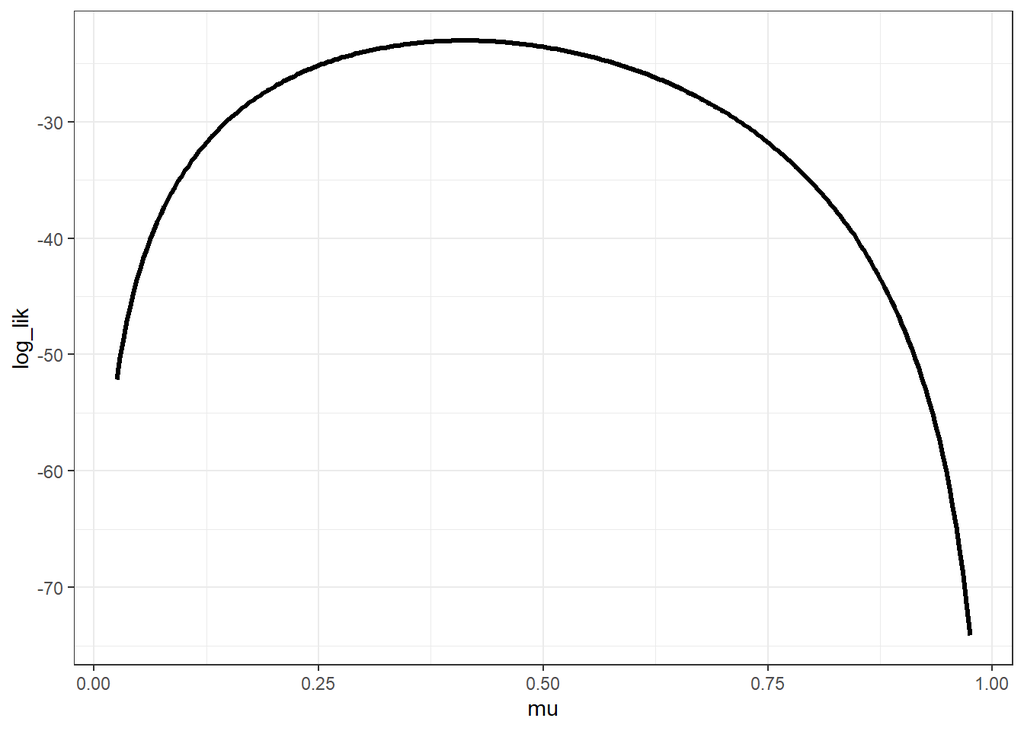

```r
xa_results %>%
  ggplot(mapping = aes(x = mu, y = log_lik)) +
  geom_line(size = 1.1) +
  theme_bw()
```

### 2f)

**Create the same line plot as in the previous question, but add an additional layer with `geom_vline()` to show a vertical reference line. Set the `xintercept` argument within `geom_vline()` to the MLE you calculated in 1b). Set the `color`, `linetype`, and `size` arguments within `geom_vline()` to `'red'`, `'dashed'`, and 1, respectively.**

#### SOLUTION

The MLE was shown to be the same as the **sample average** previously in the assignment. The MLE is therefore displayed by assigning the `mean(x)` to the `xintercept` argument of `geom_vline()`. The MLE coincides precisely with the `mu` value that maximizes the log-likelihood!

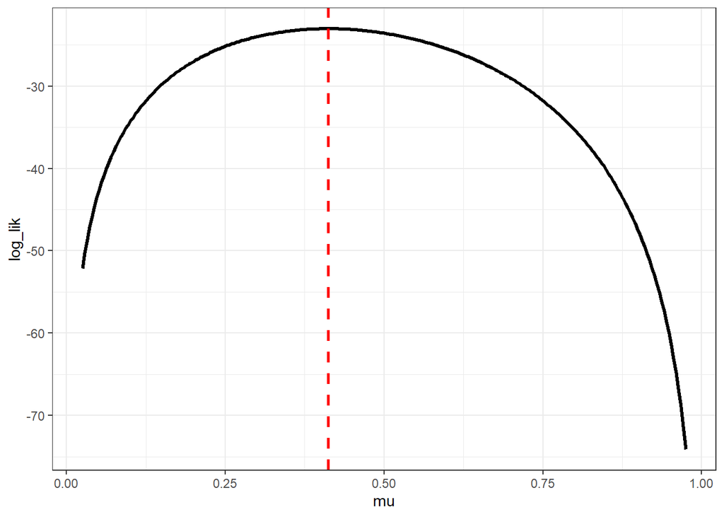

```r
xa_results %>%
  ggplot(mapping = aes(x = mu, y = log_lik)) +
  geom_line(size = 1.1) +
  geom_vline(xintercept = mean(x),
             color = 'red', linetype = 'dashed', size = 1.) +
  theme_bw()
```

### 2g)

**Describe the behavior of the log-likelihood with respect to the candidate event probability around the MLE in the plot shown in 2f). Does the curve look different near the MLE compared to other candidate values?**

#### SOLUTION

There are two points you needed to address to receive full credit for this problem. First, the obvious point is that the log-likelihood (and therefore the likelihood) reaches its maximum value at the MLE. The log-likelihood associated with every other `mu` candidate value is less than the log-likelihood located at the MLE. The most extreme examples of this idea occurs at the left and right boundaries of the plot. Probabilities near 0 and near 1 are not representative of the observed data, and thus have very low y-axis values compared to the value associated at the MLE. The second point is that the log-likelihood curve is flat at the MLE. The more formal way of describing the behavior is that the derivative or slope of the curve at the MLE is zero. The curve reached a maximum point at the “peak of the mountain”. This is an important concept because more challenging problems that must be optimized via an algorithm will exploit this behavior to identify the optimal values in order to decide when to terminate the algorithm.

## Problem 03

Let’s now consider tackling the problem from the perspective of the more general Binomial distribution.

### 3a)

The previous problems worked with the observations stored as 0s and 1s in the vector `x`. You must now summarize the observations. The Binomial distribution requires the number of events, or Hits in this case, and the number of trials, or At Bats in this case.

**Calculate the number of hits and number of at bats for the sequence of observations stored in the vector `x`. Assign the results to the corresponding variables defined in the code chunk below.**

#### SOLUTION

```r
player_hits <- sum( x )
player_atbats <- length( x )
```

### 3b)

You examined the behavior of the log-likelihood when we formulated the problem as a sequence of independent Bernoulli trials. As discussed in lecture, the Binomial distribution assumes the observations are independent Bernoulli trials! Thus, it should not matter if we analyze the problem with the Bernoulli formulation or the Binomial formulation. Let’s confirm that is indeed true!

You will work with the log of the Binomial likelihood up to a normalizing constant. That means, you do not need to consider terms that do not directly involve the unknown event probability $\mu$. Dropping or ignoring the constant terms is also referred to as the **un-normalized** likelihood.

**Write out the expression for the Binomial log-likelihood up to a normalizing constant for the number of hits $H$, given the number of at bats, $AB$, and the probability of a hit, $\mu$. The equation block is started for you, showing that the log-likelihood is just proportional to the expression on the right hand side.**

#### SOLUTION

The Binomial PMF includes three components: the Binomial coefficient, the term involving the event probability, and the term involving the non-event probability. Using the notation specific to this problem with the number of events or hits, $H$, and the number of trials or at-bats, $AB$, the Binomial PMF is:

$$p \left( H \mid AB, \mu \right) = \binom{AB}{H} \mu^{H} \left(1 - \mu
\right)^{AB - H}$$

Applying the natural log to the Binomial PMF turns the product of the three terms into the summation of the log of the three terms:

$$\log \left[ p \left( H \mid AB, \mu \right) \right] = \log\left[
\binom{AB}{H} \right] + \log\left[ \mu^{H} \right] + \log\left[ \left(1
- \mu \right)^{AB - H} \right]$$

Simplifying the above expression is simplified by the fact that we are interested in the **un-normalized** likelihood. We do not need to worry about terms that do not directly involve the unknown parameter $\mu$. The exact reason why we can ignore these terms has to do with taking derivatives of the of the log-likelihood with respect to the unknown parameter. If a term does not depend on the unknown parameter, the derivative of that term is zero! In the above expression, the natural log of the Binomial coefficient does not depend directly on $\mu$. The log of the Binomial coefficient only depends on **known** or **observed** quantities. We can thus safely drop this term and **not** change the shape of the log-likelihood *function*. The equation block below writes the log-likelihood **up to a normalizing constant** by dropping the log of the Binomial coefficient. The left hand side is no longer equal to the right hand side of the expression. The “proportional to”, $\propto$, symbol is used to represent this fact.

$$\log \left[ p \left( H \mid AB, \mu \right) \right] \propto \log\left[
\mu^{H} \right] + \log\left[ \left(1 - \mu \right)^{AB - H} \right]$$

From here, we can simplify the log-likelihood further by making use of the log-arithmetic. Exponents are “brought down” to become coefficients:

$$\log \left[ p \left( H \mid AB, \mu \right) \right] \propto H \times
\log\left[ \mu \right] + \left(AB - H\right) \log\left[ 1 - \mu \right]$$

The above expression should look familiar. We saw it in lecture and it was also derived in this assignment, if you went through the effort of simplifying the “complete” log-likelihood associated with the Bernoulli formulation in Problem 2a). The two have the same functional form and thus have same shape because the Bernoulli is a special case of the Binomial! The Binomial formulation however, is not equal to that of the Bernoulli because the more general Binomial accounts for all combinations within the Binomial coefficient. We are focused on the function *shape* which is why the two look to be the same.

### 3c)

Regardless of the formulation (Bernoulli vs Binomial), our goal is to **learn the event probability**. Thus, we still need to find the maximum likelihood estimate (MLE) for $\mu$. You graphically solved this for the Bernoulli formulation in Problem 02. Let’s now graphically find the MLE with the Binomial formulation. However, you do not need to use for-loops to compile the data necessary to create the figure when using the Binomial formulation!

**The code chunk below is started for you. A tibble (dataframe) is created with the data variable (column) `mu` assigned to the `mu_grid` object you created earlier. The tibble is passed to the `mutate()` function for you. You must create a new variable, `log_lik` within `mutate()` which is equal to the Binomial log-likelihood up to a normalizing constant. Thus, `log_lik` must equal the expression you wrote in 3a). Pipe the result into `ggplot()` and map the `x` aesthetic `mu` and the `y` aesthetic to `log_lik`. Use a `geom_line()` to display those aesthetics with `size` assigned to 1.1. As a reference, include your calculated MLE on the probability with a `geom_vline()`. The `geom_vline()` displays a vertical line at a specified `xintercept` value. You do not need to place `xintercept` within the `aes()` function. Assign the `size`, `linetype`, and `color` arguments within `geom_vline()` to 1, ‘dashed’, and ‘red’, respectively.**

#### SOLUTION

The un-normalized log-Binomial likelihood is calculated in line within the `mutate()` call below. The resulting curve looks like it is the same as what we saw previously!

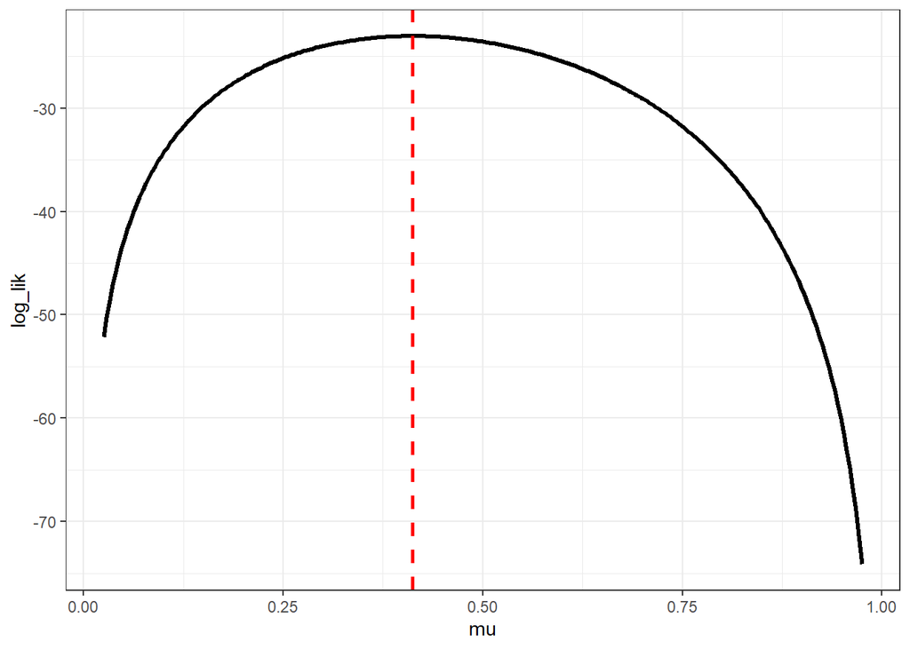

```r
tibble::tibble(
  mu = mu_grid
) %>%
  mutate(log_lik = player_hits * log(mu) + (player_atbats - player_hits) * log(1 - mu)) %>%
  ggplot(mapping = aes(x = mu, y = log_lik)) +
  geom_line(size = 1.1) +
  geom_vline(xintercept = player_hits / player_atbats,
             color = 'red', linetype = 'dashed', size = 1.) +
  theme_bw()
```

### 3d)

**How does your figure in 3c) compare to your figure in 2f)?**

#### SOLUTION

They are the same! The MLE associated with the Bernoulli formulation is also the MLE of the Binomial formulation!

### 3e)

The un-normalized Binomial likelihood you wrote in 3b) and programmed in 3c) is missing the Binomial coefficient. The Binomial coefficient properly normalizes the values of the Binomial distribution. It is not critical for the **shape** of the log-likelihood but the normalizing constant is critical for calculating probabilities.

Unless specified otherwise, you are allowed to existing functions for evaluating properly normalized densities or probability mass functions. For the Binomial distribution, the predefined function is `dbinom()`. It contains 4 input arguments: `x`, `size`, `prob`, and `log`. `x` is the number of observed events. `size` is the number of trials, so you can think of `size` as the Trial size. `prob` is the probability of observing the event. `log` is a Boolean, so it equals either `TRUE` or `FALSE`. It is a flag to specify whether to return the log of the probability, `log=TRUE`, or the probability `log=FALSE`. By default, if you do not specify `log` the `dbinom()` function assumes `log=FALSE`.

You must use the `dbinom()` function to evaluate the log-Binomial likelihood for the player, similar to what you did in 3c). However, instead of manually typing the log-likelihood up to a normalizing constant, you may use the `dbinom()` function to properly evaluate the log-likelihood.

**The code chunk below is started for you and is structured similar to that in 3c). A tibble (dataframe) is created with the data variable (column) `mu` assigned to the `mu_grid` object. The tibble is passed to the `mutate()` function for you. You must create a new variable, `log_lik` within `mutate()` which is equal to the Binomial log-likelihood. Use the `dbinom()` function to correctly calculate the Binomial log-likelihood. Pay close attention to the arguments of `dbinom()`. Pipe the result into `ggplot()` and map the `x` aesthetic `mu` and the `y` aesthetic to `log_lik`. Use a `geom_line()` to display those aesthetics with `size` assigned to 1.1. As a reference, include your calculated MLE on the probability with a `geom_vline()`. The `geom_vline()` displays a vertical line at a specified `xintercept` value. You do not need to place `xintercept` within the `aes()` function. Assign the `size`, `linetype`, and `color` arguments within `geom_vline()` to 1, ‘dashed’, and ‘red’, respectively.**

*HINT*: Do not forget to set the `log` flag appropriately!

#### SOLUTION

The log-likelihood is calculated within the `mutate()` call by using the `dbinom()` function. The curve is same shape as before!

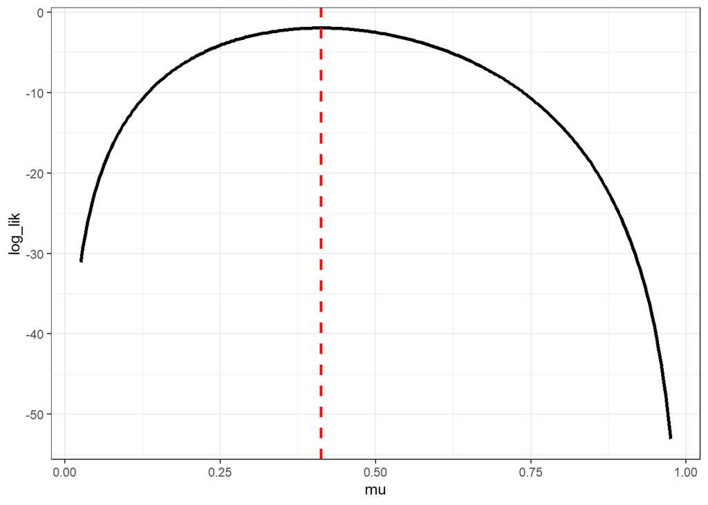

```r
tibble::tibble(
  mu = mu_grid
) %>%
  mutate(log_lik = dbinom(x = player_hits, size = player_atbats, prob = mu, log=TRUE)) %>%
  ggplot(mapping = aes(x = mu, y = log_lik)) +
  geom_line(size = 1.1) +
  geom_vline(xintercept = player_hits / player_atbats,
             color = 'red', linetype = 'dashed', size = 1.) +
  theme_bw()
```

### 3f)

**How does your figure in 3e) compare to the figures in 3c) and 2f)?**

#### SOLUTION

Qualitatively they are the same! The shapes are identical and the MLE corresponds to the same $\mu$ value! The only difference is the values on the y-axis. The `dbinom()` function includes the Binomial coefficient, and thus the “constant terms” which we had dropped in our derivations are included. The normalizing constant only effects the scale but NOT the shape of the curve!

## Problem 04

You estimated the event probability (probability of a hit) by maximizing the likelihood. It’s now time to use Bayesian methods to learn a **posterior** distribution for the unknown parameter. This distribution will fully represent everything we know about the parameter, based on data and our assumptions. You will summarize this distribution to describe the uncertainty in the parameter, and representative values such as the posterior mean and most probable value (the posterior mode).

As discussed in lecture, Bayesian methods require **prior** distributions. These distributions represent what we believe about the unknowns. Priors enable combining expert opinion with the data in a controlled and consistent manner. The prior allows us to specify bounds or constraints on the parameter and thus prevents the learning process from being fooled by noise or small sample sizes.

Your goal is to learn the unknown event (hit) probability. You must therefore specify a prior belief about the probability that a professional baseball player gets a hit. You will use a **Beta** distribution to encode the prior belief on the event probability. The Beta **shape** parameters control the location, width (uncertainty), and skew (asymmetry) of the Beta distribution. Encoding our prior belief therefore comes down to specifying the shape parameter values.

Instead of focusing on how we should optimally decide those shape parameters, your task is to examine the influence of the prior belief on the posterior result. You will thus try out two different priors and compare the resulting posterior distributions. Determining the “most appropriate” prior is something we will discuss later in the semester.

The code chunk below defines two sets of shape parameters. The uniform set with both shape parameters equal to 1, and the “informative” set which to different values. Both sets refer to the first shape parameter as $a$ and the second shape parameter as $b$. The R function `dbeta()` refers to $a$ as the `shape1` argument and $b$ as the `shape2` argument.

```r
a_uniform <- 1
b_uniform <- 1

a_inform <- 10
b_inform <- 30
```

### 4a)

**What is the prior number of trials associated with the two sets of shape parameters?**

#### SOLUTION

Prior number of trials is the sum of the two shape parameters! The Uniform prior distribution’s prior number of trials is just 2. The Uniform prior places no “prior bias” on any interval because it has limited experience! The Uniform prior represents observing 2 data points previously. Following the baseball example in this assignment, this is analogous to only having watched 2 at bats previously. A single half-inning has at minimum 3 at bats, thus the Uniform prior represents not even having seen a half-inning of baseball!

```r
a_uniform + b_uniform
```

```
## [1] 2
```

```r
a_inform + b_inform
```

```
## [1] 40
```

### 4b)

**What is the prior expected value (mean) for the event (hit) probability associated with the two sets of shape parameters?**

#### SOLUTION

The mean of a Beta is the shape1 parameter divided by the sum of the two shape parameters. The Uniform prior has a prior mean of 0.5.

```r
a_uniform / (a_uniform + b_uniform)
```

```
## [1] 0.5
```

The informative prior however has a prior mean of 0.25.

```r
a_inform / (a_inform + b_inform)
```

```
## [1] 0.25
```

Thus, the two priors have the expected or average hit probability “located” at different values!

### 4c)

You will visualize the prior distributions and are allowed to calculate the Beta density with the `dbeta()` function. The first argument to `dbeta()` is the probability parameter, `x`. The second argument to `dbeta()` is `shape1`, the third argument to `dbeta()` is `shape2`. You do not need to set any other argument to `dbeta()` for this question.

**Plot the two types of prior distributions on the unknown event (hit) probability $\mu$. The Beta pdf can be evaluated with the `dbeta()` function. You must plot the prior with `ggplot2`. The code chunks below are started for you. The $\mu$ values are assigned to the `mu` column using the `mu_grid` object you defined earlier.**

#### SOLUTION

Plot the Uniform prior on $\mu$. As the name states, the density is uniformly or evenly distributed between 0 and 1. No interval is more likely than any other interval. The prior mean of 0.5 is simply the midpoint of the Uniform prior distribution.

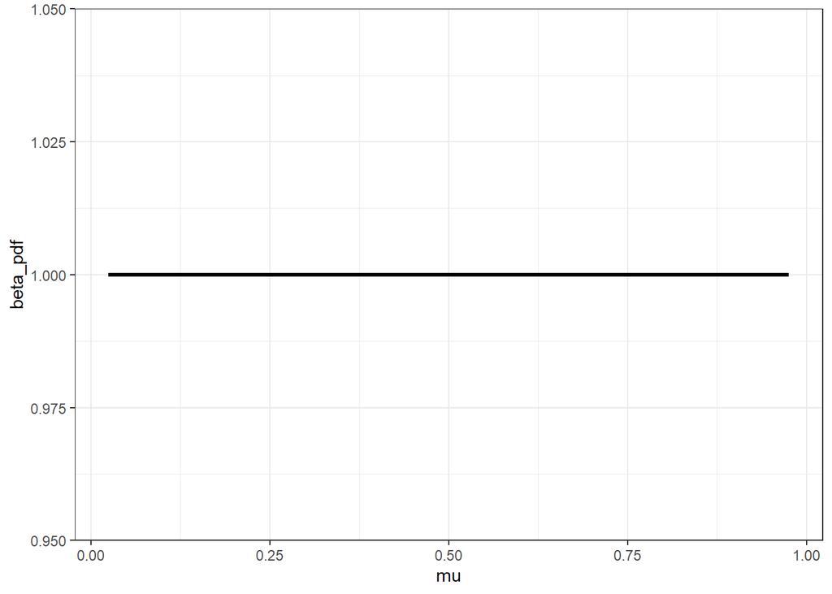

```r
tibble::tibble(
  mu = mu_grid
) %>%
  mutate(beta_pdf = dbeta(mu, a_uniform, b_uniform)) %>%
  ggplot(mapping = aes(x = mu, y = beta_pdf)) +
  geom_line(size = 1.1) +
  theme_bw()
```

Plot the informative prior on $\mu$. The informative prior identifies two interval to be not appropriate while an inner interval as more likely than the other two. The two “ruled out” intervals are hit probabilities, $\mu$, near 0 and hit probabilities, $\mu$, greater than 0.5. Thus, the informative prior “thinks” or **believes** there is no chance a Major League Baseball player will get a hit 0% of the time. After all, the ball player is paid to play the game. The ball player will not have a job for long if he gets zero hits! The informative prior also rules out hit probabilities greater than 50%. Thus, the prior does not think a professional player will successfully get a hit 50% of the time. This reflects the fact that professional hitters fail more often than they succeed.

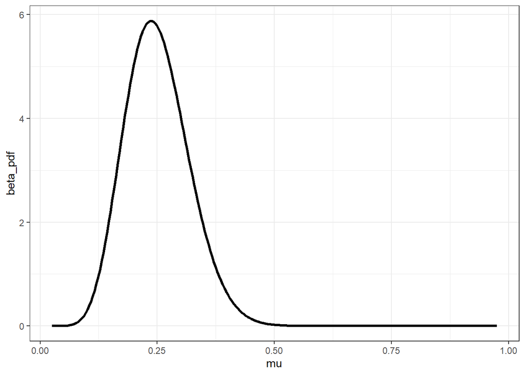

```r
tibble::tibble(
  mu = mu_grid
) %>%
  mutate(beta_pdf = dbeta(mu, a_inform, b_inform)) %>%
  ggplot(mapping = aes(x = mu, y = beta_pdf)) +
  geom_line(size = 1.1) +
  theme_bw()
```

You were not required to do so, but it can be illustrative to directly compare the two prior distributions on the same plot. The code chunk below combines the two tibbles (dataframes) into a single tibble. This single tibble includes a column `from_prior` which uniquely identifies the prior assumption the density is associated with. The Informative prior constrains the possible values of the event probability to be located roughly between 13% and 38%. Event probabilities outside this interval have much lower density values and thus effectively rules them out.

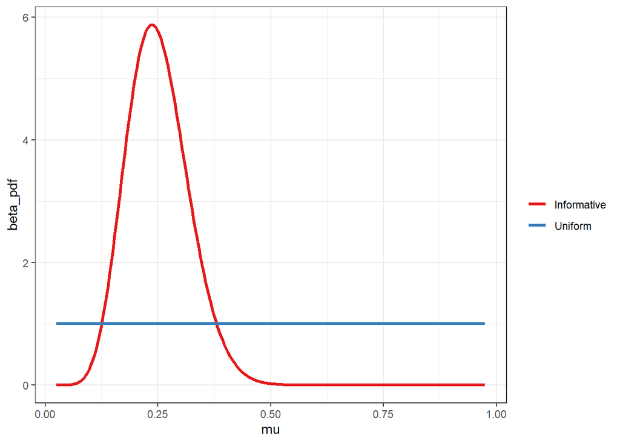

```r
tibble::tibble(
  mu = mu_grid
) %>%
  mutate(beta_pdf = dbeta(mu, shape1 = a_uniform, shape2 = b_uniform),
         from_prior = 'Uniform') %>%
  bind_rows(tibble::tibble(mu = mu_grid) %>%
              mutate(beta_pdf = dbeta(mu, shape1 = a_inform, shape2 = b_inform),
                     from_prior = 'Informative')) %>%
  ggplot(mapping = aes(x = mu, y = beta_pdf)) +
  geom_line(size = 1.1,
            mapping = aes(color = from_prior)) +
  scale_color_brewer('', palette = 'Set1') +
  theme_bw()
```

### 4d)

**How do the two priors compare? Are there event probability values that are “ruled out” by either of the priors?**

#### SOLUTION

Obviously the UNIFORM prior has a uniform distribution! The uniform prior has no prior bias or weight or concentration in any interval. Thus, no $\mu$ values are prevented. However, the informative prior concentrates in the interval around 0.25. The lowest values near 0 are prevented since the density is near zero, as well as the highest values greater than 0.5. Thus, the informative prior says a professional baseball player will get at least a few hits, but will not hit successfully in more than 50% of the at bats!

## Problem 05

Now that you have practiced working with the likelihood and the prior, it is time to study the posterior! However, before executing the analysis for the current baseball problem, you will manipulate the expressions to get a better understanding of the posterior distribution in this application.

The previous problems in this assignment used notation consistent with the baseball example. However, you will use more generic nomenclature and syntax in this problem to be consistent with lecture. Thus, you will consider a Binomial likelihood with $m$ events out of $N$ trials. You are interested in learning the unknown event probability $\mu$ by combining the observations with the prior. You are using a Beta prior with prior shape parameters, $a$ and $b$.

### 5a)

You previously wrote out the log-Binomial likelihood up to a normalizing constant in terms hits and at bats. You will rewrite that expression, but this time with the generic variables for the number of events $m$ out of a generic number of trials $N$.

**Write out the un-normalized log-likelihood for the Binomial likelihood with $m$ events out of $N$ trials and unknown event probability $\mu$.**

#### SOLUTION

We went through the derivation of the un-normalized Binomial likelihood in 3b). The result is the log of the event probability times the number of events plus the log of the non-event probability times the number of non-events.

$$\log \left( p \left( m \mid N, \mu \right) \right) \propto m \log\left(
\mu \right) + \left(N - m\right) \log \left(1 - \mu \right)$$

We can derive this expression by starting from the Binomial likelihood, just as we did in 3b):

$$p \left( m \mid N, \mu \right) = \binom{N}{m} \mu^{m} \left(1 - \mu
\right)^{N - m}$$

Apply the natural log:

$$\log \left[ p \left( m \mid N, \mu \right) \right] = \log\left[
\binom{N}{m} \right] + \log\left[ \mu^{m} \right] + \log\left[ \left(1 -
\mu \right)^{N - m} \right]$$

As discussed in 3b), the log of the Binomial coefficient can be dropped because it does not directly depend on $\mu$. Simplifying the expression through log-arithmetic then provides the log-likelihood up to a normalizing constant:

$$\log \left( p \left( m \mid N, \mu \right) \right) \propto m \log\left(
\mu \right) + \left(N - m\right) \log \left(1 - \mu \right)$$

### 5b)

**Write the log-density of the Beta distribution up to a normalizing constant on the unknown event probability $\mu$ with shape parameters $a$ and $b$.**

#### SOLUTION

The Beta distribution has the same functional form as the Binomial. The Beta PDF includes the event probability raised to a power times the non-event probability raised to a power. The “interesting” part of the Beta PDF ignores the normalizing constant (the portion involving the Gamma functions):

$$p \left( \mu \mid a, b \right) \propto \mu^{a-1} \left(1 -
\mu\right)^{b-1}$$

Applying the natural log and simplifying with log-arithmetic yields an expression similar to the log Binomial PMF. The log of the Beta PDF is proportional to the log of the event probability times a coefficient plus the log of the non-event probability times a different coefficient:

$$\log \left( p \left( \mu \mid a, b \right) \right) \propto \left(a -
1\right) \log\left[ \mu \right] + \left(b - 1\right) \log \left[ 1 - \mu
\right]$$

### 5c)

We already know that since the Beta is conjugate to the Binomial, the posterior distribution on the unknown event probability $\mu$ is also a Beta. You must practice working through the derivation of the updated shape parameters $a_{new}$ and $b_{new}$. The log-likelihood was written in Problem 5a) and the log-prior in Problem 5b). In this problem you must add the un-normalized log-likelihood to the un-normalized log-prior, then perform the required algebra to derive $a_{new}$ and $b_{new}$.

**Derive the expressions for the updated or posterior Beta shape parameters. You must show all steps in the derivation. You are allowed to use multiple equation blocks if that’s easier for you to type with.**

#### SOLUTION

Step 1, add the un-normalized log-likelihood to the un-normalized log-prior:

$$m \log\left(\mu\right) + \left(N-m\right) \log \left(1-\mu\right) +
\left(a - 1\right) \log \left( \mu \right) + \left(b - 1\right) \log
\left(1 - \mu \right)$$

Group like-terms together.

$$\left(m + a - 1 \right) \log \left(\mu \right) + \left(N - m + b - 1
\right) \log \left(1 - \mu \right)$$

The coefficient acting on $\log\left(\mu\right)$ is $\left(m + a - 1\right)$. Thus, the updated or posterior $a_{new}$ parameter must be:

$$a_{new} = a + m$$

The coefficient acting on $\log\left(1 - \mu\right)$ is $\left(N - m + b - 1\right)$. Thus, the updated or posterior $b_{new}$ parameter must be:

$$b_{new} = b + \left(N - m\right)$$

The un-normalized log-posterior can then be written as:

$$\left(a_{new} - 1\right) \log \left( \mu \right) + \left(b_{new} - 1
\right) \log \left(1 - \mu \right)$$

It is important to note that the $-1$’s are not “absorbed” into the $a_{new}$ and $b_{new}$ shape parameters. The exponents associated with the $\mu$ and $\left(1 - \mu \right)$ terms in the Beta density are defined as $a - 1$ and $b - 1$, respectively.

### 5d)

Since the posterior distribution on $\mu$ is a Beta, a formula exists for the posterior mode (Max a-posterior estimate). However, you will practice deriving the posterior mode through differentiation of the un-normalized log-posterior. You can always double check your answer with the known formula for the mode of a Beta!

**Derive the expression for the first derivative of the un-normalized log-posterior with respect to the unknown event probability $\mu$. Write out the derivative in terms of the updated shape parameters $a_{new}$ and $b_{new}$.**

#### SOLUTION

The un-normalized log posterior on the unknown event probability, $\mu$, was written out in the solution above, but let’s write it out again below.

$$\log \left( p\left( \mu \mid m, N \right) \right) \propto \left(a_{new}
- 1 \right) \log \left( \mu \right) + \left( b_{new} - 1 \right) \log
\left( 1 - \mu \right)$$

The derivative of the log-posterior with respect to $\mu$ can then be written as the sum of the derivatives of the “event” and the “non-event” terms:

$$\frac{d}{d \mu} \left( \log \left( p\left( \mu \mid m, N \right) \right)
\right) = \frac{d}{d \mu} \left( \left(a_{new} - 1 \right) \log \left(
\mu \right) \right) + \frac{d}{d \mu} \left( \left( b_{new} - 1 \right)
\log \left( 1 - \mu \right) \right)$$

The posterior shape parameters are constants with respect to $\mu$ so the right hand side of the expression simplifies to:

$$\left(a_{new} - 1 \right) \frac{d}{d \mu} \left( \log \left(\mu \right)
\right) + \left( b_{new} - 1\right) \frac{d}{d \mu} \left( \log \left(1
- \mu \right) \right)$$

We therefore need to take the derivative of $\log \left( \mu \right)$ and $\log \left( 1 - \mu \right)$ with respect to $\mu$. The derivative of $\log \left( \mu \right)$ is:

$$\frac{d}{d \mu} \left( \log \left(\mu \right) \right) = \frac{1}{\mu}$$

The derivative of $\log \left( 1 - \mu \right)$ takes a little extra work, requiring a substitution and the chain rule. Please see the math review video on Canvas for help if that derivative was difficult for you to work through. The derivative is:

$$\frac{d}{d \mu} \left( \log \left(1 - \mu \right) \right) = -\frac{1}{1
- \mu}$$

Substituting both derivatives back into the expression for the derivative of the log-posterior with respect to $\mu$ gives:

$$\frac{d}{d \mu} \left( \log \left( p\left( \mu \mid m, N \right) \right)
\right) = \frac{a_{new} - 1}{\mu} - \frac{b_{new} -1}{1 - \mu}$$

### 5e)

**Set the derivative from your solution to Problem 5d) equal to zero and solve for the posterior mode of the unknown event probability. Denote the posterior mode as $\mu_{MAP}$.**

#### SOLUTION

The posterior mode or max a posteriori (MAP) estimate is found by setting the derivative of the log-posterior with respect to $\mu$ equal to zero.

$$\frac{d}{d \mu} \left( \log \left( p\left( \mu \mid m, N \right) \right)
\right) = \frac{a_{new} - 1}{\mu} - \frac{b_{new} -1}{1 - \mu} = 0$$

We need to now solve for $\mu$. The first step is to move the “non-event” term to the right hand side.

$$\frac{a_{new} - 1}{\mu} = \frac{b_{new} -1}{1 - \mu}$$

Next, multiply through to remove the fractions:

$$\left( a_{new} - 1\right) \left(1 - \mu \right) = \left( b_{new} -
1\right) \mu$$

Multiply through to expand the terms on both sides of the equation:

$$\left(a_{new} - 1\right) - \left(a_{new} -1 \right) \mu = \left( b_{new}
- 1\right) \mu$$

Group the terms involving $\mu$ together:

$$\left(a_{new} - 1\right) = \left( b_{new} - 1 + a_{new} - 1\right) \mu =
\left( b_{new} + b_{new} - 2\right) \mu$$

Solve for the MAP, $\mu_{MAP}$:

$$\mu_{MAP} = \frac{a_{new} - 1}{a_{new} + b_{new} - 2}$$

This expression is identical to the formula for the **mode** of a Beta distribution with shape parameters $a_{new}$ and $b_{new}$!

If you look closely at the formula for the mode, the denominator has 2 subtracted from the sum of the shape parameters. We know that the sum of the shape parameters represents the *effective* number of trials. Thus, the Beta can only have a unique defined mode if there are more than 2 *effective* trials!

## Problem 06

Now that you’ve worked with the posterior Beta in greater detail, it is time to execute the Bayesian analysis for the baseball problem.

As a reminder, there are two sets of prior shape parameters. The uniform prior is defined by `a_uniform` and `b_uniform`. The informative prior is defined by `a_inform` and `b_inform`. The observations are stored in the variables `player_hits` and `player_atbats`.

### 6a)

**Calculate the updated or posterior shape parameters, $a_{new}$ and $b_{new}$, using the observations and the two sets of prior shape parameters.**

**This problem is open ended, you are free to make the calculations anyway you like. However, you must display the updated shape parameters to the screen. Your results should be clearly marked as to which prior the posterior shape parameters are associated with.**

#### SOLUTION

There are numerous ways to make the calculations and to organize the results. The code chunk below demonstrates one way to solve this problem. The `post_results` tibble (dataframe) is created with columns, `a`, `b`, `prior_type`, `m`, and `N`. The `a` and `b` columns are the prior shape parameters, while `m` and `N` are the observations. The `prior_type` column identifies the prior the shape parameteres are associated with. These columns are used to calculate the posterior (updated) shape parameters, `a_new` and `b_new`.

```r
post_results <- tibble::tibble(
  a = c(a_uniform, a_inform),
  b = c(b_uniform, b_inform),
  prior_type = c("uniform", "inform")
) %>%
  mutate(m = player_hits,
         N = player_atbats) %>%
  mutate(a_new = a + m,
         b_new = b + (N - m))
```

The `post_results` object is displayed below. The observations `m` and `N` are the same for both priors. The differences in the `a_new` and `b_new` values is due to the differences in the prior shape parameter values. The informative prior has larger prior shape parameters and thus yields larger posterior shape parameter values.

```r
post_results
```

```
## # A tibble: 2 × 7
##       a     b prior_type     m     N a_new b_new
##   <dbl> <dbl> <chr>      <dbl> <int> <dbl> <dbl>
## 1     1     1 uniform       14    34    15    21
## 2    10    30 inform        14    34    24    50
```

The code chunk below only shows the posterior shape parameters associated with the two priors to streamline the display.

```r
post_results %>%
  select(`From Prior` = prior_type, a_new, b_new)
```

```
## # A tibble: 2 × 3
##   `From Prior` a_new b_new
##   <chr>        <dbl> <dbl>
## 1 uniform         15    21
## 2 inform          24    50
```

### 6b)

**Calculate the posterior mean, mode, 5th percentile (0.05 quantile), and 95th percentile (0.95 quantile) for the posteriors associated with the two prior types. You should use your results from Problem 6a) for the updated or posterior beta shape parameters**

**Display your results as a dataframe or tibble.**

*NOTE*: The `qbeta()` function allows calculating the quantiles associated with a particular probability of interest.

#### SOLUTION

The posterior mean is calculated using the formula for the mean of a Beta distribution provided in lecture. Regardless of whether the Beta is the prior or posterior, the mean is the $a$ shape parameter (`shape1` in R) divided by the sum of the shape parameters. The mean of a Beta is therefore the number of events divided by the number of trials! The posterior mode is calculated using the formula derived in 5e). Lastly, the quantiles are calculated using the `qbeta()` function. The 0.05 and 0.95 quantiles were selected in order to provide the bounds on the posterior middle 90% uncertainty interval. The results are displayed below.

```r
post_results %>%
  mutate(post_mean = a_new /(a_new + b_new),
         post_mode = (a_new - 1) / (a_new + b_new - 2),
         post_q05 = qbeta(0.05, a_new, b_new),
         post_q95 = qbeta(0.95, a_new, b_new)) %>%
  select(prior_type, starts_with('post_'))
```

```
## # A tibble: 2 × 5
##   prior_type post_mean post_mode post_q05 post_q95
##   <chr>          <dbl>     <dbl>    <dbl>    <dbl>
## 1 uniform        0.417     0.412    0.286    0.553
## 2 inform         0.324     0.319    0.238    0.416
```

The two different priors yield very different posterior means! The posterior mean associated with the Uniform prior is 0.417. The batter is therefore expected to have a hit probability near 42%! However, the informative prior yields a posterior mean close to 0.324. Thus, the informative prior yields an updated belief expecting the player to have a hit probability closer to one third! These are just estimates though and we should always consider the **uncertainty** in the values. The posterior middle 90% uncertainty interval are also different! The 90% uncertainty intervals are printed again below for convenience. The 90% uncertainty interval associated with the Uniform prior states that the batter’s hit probability is between roughly 29% and 55%. However, the informative prior yields a 90% uncertainty interval between roughly 24% and 42%. Thus, the informative prior rules out hit probabilities greater than 50%, while the Uniform prior results in a posterior **belief** that thinks there’s a slim chance the batter hits the ball successfully 50% of the time. Also, it is interesting that the informative prior’s associated posterior 0.95 Quantile is close to the posterior mode associated with the Uniform prior.

```r
post_results %>%
  mutate(post_mean = a_new /(a_new + b_new),
         post_mode = (a_new - 1) / (a_new + b_new - 2),
         post_q05 = qbeta(0.05, a_new, b_new),
         post_q95 = qbeta(0.95, a_new, b_new)) %>%
  select(`From Prior` = prior_type, `Posterior Q05` = post_q05, `Posterior Q95` = post_q95)
```

```
## # A tibble: 2 × 3
##   `From Prior` `Posterior Q05` `Posterior Q95`
##   <chr>                  <dbl>           <dbl>
## 1 uniform                0.286           0.553
## 2 inform                 0.238           0.416
```

You were not required to visualize the posterior summary statistics. You needed to display the summary statistics to receive full credit. However, the code chunk below visualizes the posterior summary statistics in a style consistent with the lecture slides. The posterior 90% uncertainty interval is represented by the vertical line. The posterior mean is shown by the solid dot and the posterior mode is the red cross.

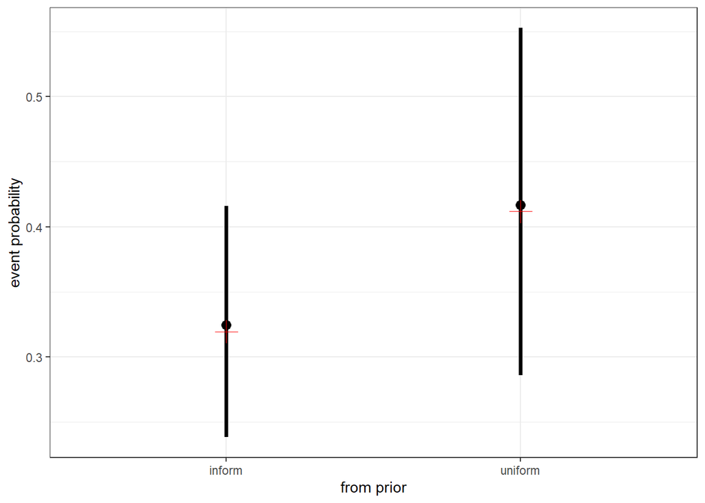

```r
post_results %>%
  mutate(post_mean = a_new /(a_new + b_new),
         post_mode = (a_new - 1) / (a_new + b_new - 2),
         post_q05 = qbeta(0.05, a_new, b_new),
         post_q95 = qbeta(0.95, a_new, b_new)) %>%
  ggplot(mapping = aes(x = prior_type)) +
  geom_linerange(mapping = aes(ymin = post_q05,
                               ymax = post_q95,
                               group = prior_type),
                 size = 1.25) +
  geom_point(mapping = aes(y = post_mean),
             shape = 16, size = 3) +
  geom_point(mapping = aes(y = post_mode),
             shape = 3, size = 5, color = 'red') +
  labs(x = 'from prior', y = 'event probability') +
  theme_bw()
```

### 6c)

Problem 6b) required that you summarize the posterior Beta distribution. This problem requires that you visualize the posterior Beta density associated with the two prior types. You will create the visualizations similar to what you did in 4c), but you must use the updated or posterior shape parameters, instead of the prior shape parameters.

**Plot the two posterior distributions on the unknown event (hit) probability $\mu$. The Beta pdf can be evaluated with the `dbeta()` function. You must plot the posterior with `ggplot2`. The code chunks below are started for you. The $\mu$ values are assigned to the `mu` column using the `mu_grid` object you defined earlier. Use the posterior shape parameters you calculated in 6a) in the appropriate code chunk below.**

#### SOLUTION

Plot the posterior Beta associated with the uniform prior.

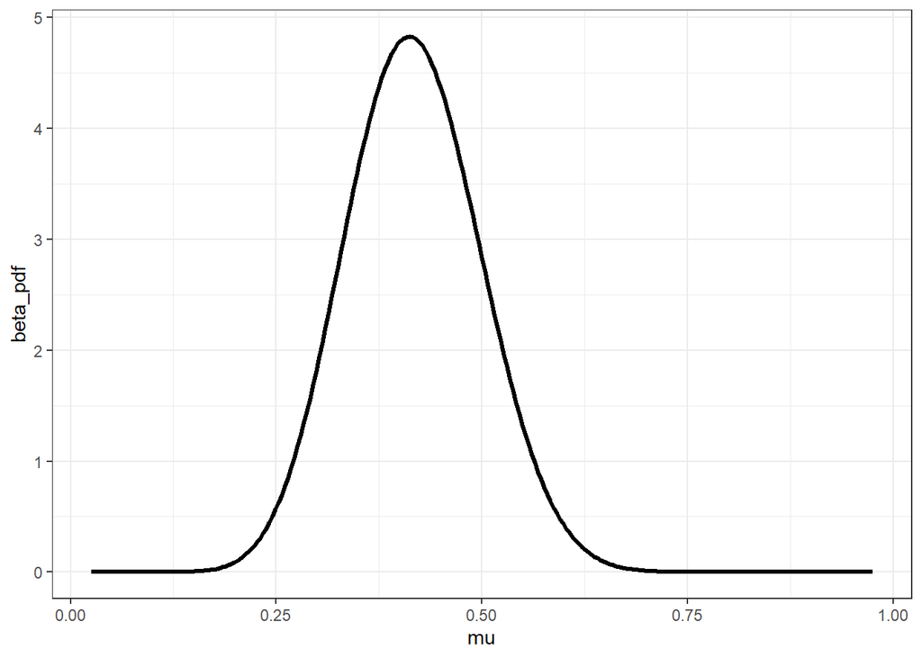

```r
tibble::tibble(
  mu = mu_grid
) %>%
  mutate(beta_pdf = dbeta(mu, shape1 = 15, shape2 = 21)) %>%
  ggplot(mapping = aes(x = mu, y = beta_pdf)) +
  geom_line(size = 1.1) +
  theme_bw()
```

Plot the posterior Beta associated with the informative prior.

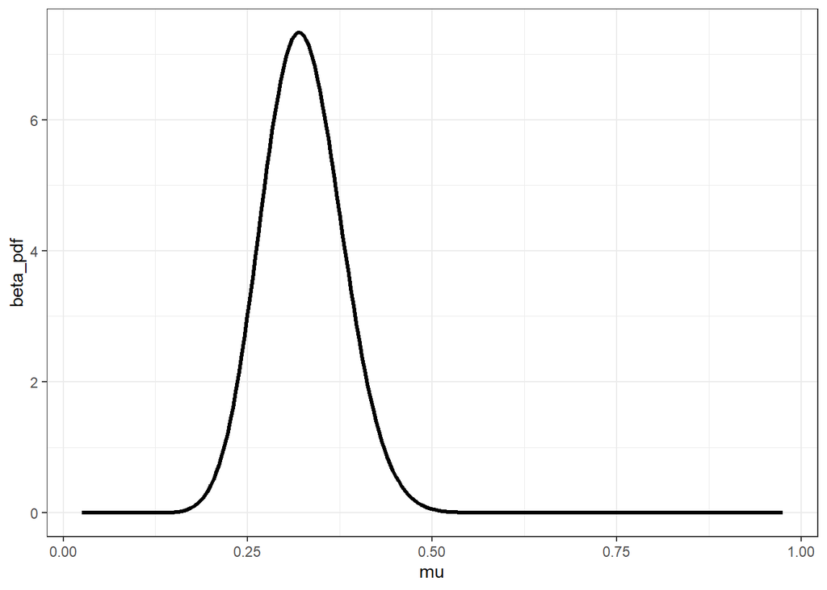

```r
tibble::tibble(
  mu = mu_grid
) %>%
  mutate(beta_pdf = dbeta(mu, shape1 = 24, shape2 = 50)) %>%
  ggplot(mapping = aes(x = mu, y = beta_pdf)) +
  geom_line(size = 1.1) +
  theme_bw()
```

You were only required to create the two plots above, but it is useful to overlay the two posteriors on the same graphic. This allows us to directly compare them and get a sense of how the informative prior constrains the possible values of the event probability. The posterior mode associated with the Uniform prior is situated near a low density interval for the posterior associated with the Informative prior. The Informative prior prevents the larger values of the event probability **even though** the data suggests the probability should be higher than 40%!

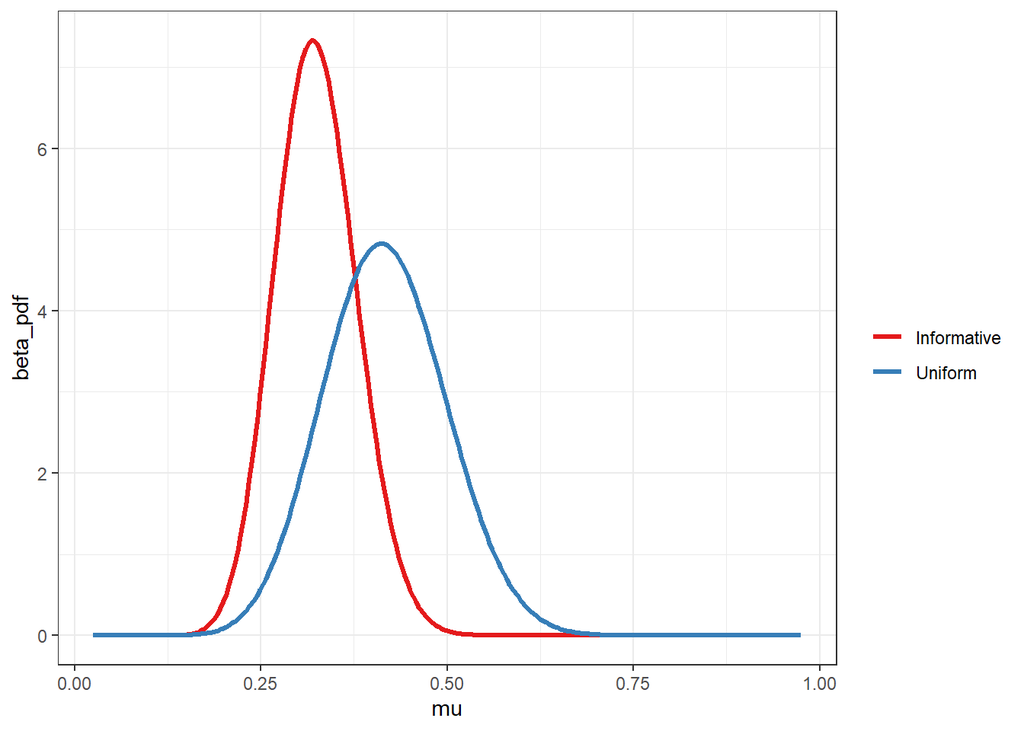

```r
tibble::tibble(
  mu = mu_grid
) %>%
  mutate(beta_pdf = dbeta(mu, shape1 = 15, shape2 = 21),
         from_prior = 'Uniform') %>%
  bind_rows(tibble::tibble(mu = mu_grid) %>%
              mutate(beta_pdf = dbeta(mu, shape1 = 24, shape2 = 50),
                     from_prior = 'Informative')) %>%
  ggplot(mapping = aes(x = mu, y = beta_pdf)) +
  geom_line(size = 1.1,
            mapping = aes(color = from_prior)) +
  scale_color_brewer('', palette = 'Set1') +
  theme_bw()
```

## Problem 07

The data provided to you at the beginning of the assignment is just a small sample of the at bats for this particular Major League Baseball player. The player has played in the MLB season June 2022 and has required many more at bats. You have evaluated the posterior based on the small sample size under two different prior assumptions. Let’s now examine how the posterior behaves under larger sample sizes by using the data from the entire season.

The code chunk below provides the season total hits (number of events) and at bats (number of trials) for this player (at least up to the creation of this assignment).

```r
season_hits <- 62

season_atbats <- 284
```

You will use the same two sets of prior shape parameters as in the previous problem. However, you will use the larger sample size observations for this question.

### 7a)

**Calculate the updated or posterior shape parameters, $a_{new}$ and $b_{new}$, using the season (larger sample size) observations and the two sets of prior shape parameters.**

**This problem is open ended, you are free to make the calculations anyway you like. However, you must display the updated shape parameters to the screen. Your results should be clearly marked as to which prior the posterior shape parameters are associated with.**

#### SOLUTION

There are many ways to organize the results for this problem. The solution shown below is one such way and is consistent with the approach provided in 6a). The difference is that the observations are associated with the larger sample size.

```r
season_results <- tibble::tibble(
  a = c(a_uniform, a_inform),
  b = c(b_uniform, b_inform),
  prior_type = c("uniform", "inform")
) %>%
  mutate(m = season_hits,
         N = season_atbats) %>%
  mutate(a_new = a + m,
         b_new = b + (N - m))
```

You needed to display the posterior shape parameters and regardless of how you organized the results, your values for `a_new` and `b_new` must be the same as those shown below.

```r
season_results
```

```
## # A tibble: 2 × 7
##       a     b prior_type     m     N a_new b_new
##   <dbl> <dbl> <chr>      <dbl> <dbl> <dbl> <dbl>
## 1     1     1 uniform       62   284    63   223
## 2    10    30 inform        62   284    72   252
```

The code chunk below only shows the posterior shape parameters associated with the two priors to streamline the display.

```r
season_results %>%
  select(`From Prior` = prior_type, a_new, b_new)
```

```
## # A tibble: 2 × 3
##   `From Prior` a_new b_new
##   <chr>        <dbl> <dbl>
## 1 uniform         63   223
## 2 inform          72   252
```

### 7b)

**Calculate the posterior mean, mode, 5th percentile (0.05 quantile), and 95th percentile (0.95 quantile) for the posteriors associated with the two prior types. You should use your results from Problem 7a) for the updated or posterior beta shape parameters**

**Display your results as a dataframe or tibble.**

*NOTE*: The `qbeta()` function allows calculating the quantiles associated with a particular probability of interest.

#### SOLUTION

Again there are many ways to calculate the posterior summary statistics. The solution shown below is one such way, but you were required to display the results in an organized manner. Your numbers must match the numbers displayed below.

```r
season_results %>%
  mutate(post_mean = a_new /(a_new + b_new),
         post_mode = (a_new - 1) / (a_new + b_new - 2),
         post_q05 = qbeta(0.05, a_new, b_new),
         post_q95 = qbeta(0.95, a_new, b_new)) %>%
  select(prior_type, starts_with('post_'))
```

```
## # A tibble: 2 × 5
##   prior_type post_mean post_mode post_q05 post_q95
##   <chr>          <dbl>     <dbl>    <dbl>    <dbl>
## 1 uniform        0.220     0.218    0.181    0.262
## 2 inform         0.222     0.220    0.185    0.261
```

Let’s examine the posterior mean in greater detail. You were not required to do anything for this question, but if you look closely the posterior mean is roughly 22% regardless of the prior! The code chunk below isolates the posterior mean “coming from” the two priors:

```r
season_results %>%
  mutate(post_mean = a_new /(a_new + b_new),
         post_mode = (a_new - 1) / (a_new + b_new - 2),
         post_q05 = qbeta(0.05, a_new, b_new),
         post_q95 = qbeta(0.95, a_new, b_new)) %>%
  select(`From Prior` = prior_type, `Posterior Mean` = post_mean)
```

```
## # A tibble: 2 × 2
##   `From Prior` `Posterior Mean`
##   <chr>                   <dbl>
## 1 uniform                 0.220
## 2 inform                  0.222
```

Why are the posterior means roughly the same? The larger sample sizes means the prior shape parameters have less influence on the posterior shape parameters. For example, the prior `a` parameters are 1 and 10 for the Uniform and Informative priors, respectively. The posterior shape parameter `a_new` is the prior `a` plus the number of events, `m`. Larger sample sizes, specifically more events, overwhelms any difference across the priors. Thus, the prior has less impact when the sample size gets large!

To put it another way, the ratio between the two prior $a$ parameters is 0.1:

```r
a_uniform / a_inform
```

```
## [1] 0.1
```

However, the ratio between the two posterior $a_{new}$ parameters is closer to 1:

```r
(a_uniform + season_hits) / (a_inform + season_hits)
```

```
## [1] 0.875
```

Thus, the posterior shape parameter is influenced more from the data than the prior!

Visualizing the posterior summary statistics is an even easier way to show how similar they are. Again, you were not required to do this. The figure below makes it very clear the prior has minimal influence on the posterior for the **larger sample size** case!

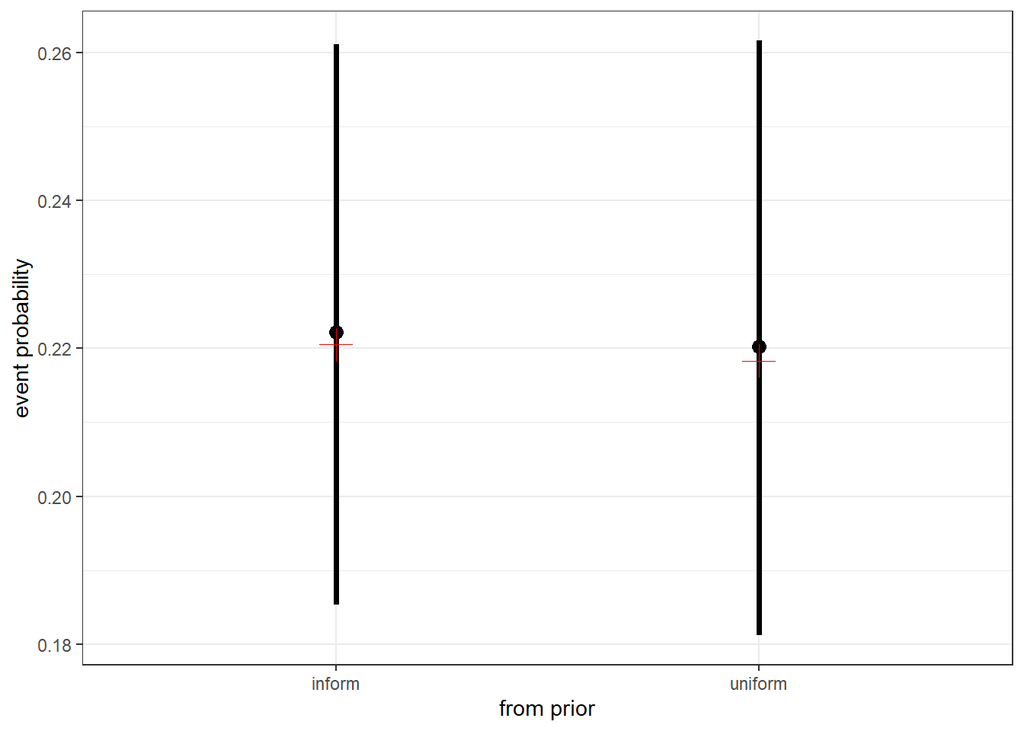

```r
season_results %>%
  mutate(post_mean = a_new /(a_new + b_new),
         post_mode = (a_new - 1) / (a_new + b_new - 2),
         post_q05 = qbeta(0.05, a_new, b_new),
         post_q95 = qbeta(0.95, a_new, b_new)) %>%
  ggplot(mapping = aes(x = prior_type)) +
  geom_linerange(mapping = aes(ymin = post_q05,
                               ymax = post_q95,
                               group = prior_type),
                 size = 1.25) +
  geom_point(mapping = aes(y = post_mean),
             shape = 16, size = 3) +
  geom_point(mapping = aes(y = post_mode),
             shape = 3, size = 5, color = 'red') +
  labs(x = 'from prior', y = 'event probability') +
  theme_bw()
```

### 7c)

Problem 7b) required that you summarize the posterior Beta distribution. This problem requires that you visualize the posterior Beta density associated with the two prior types. You will create the visualizations similar to what you did in 4c), but you must use the updated or posterior shape parameters, instead of the prior shape parameters.

**Plot the two posterior distributions on the unknown event (hit) probability $\mu$. The Beta pdf can be evaluated with the `dbeta()` function. You must plot the posterior with `ggplot2`. The code chunks below are started for you. The $\mu$ values are assigned to the `mu` column using the `mu_grid` object you defined earlier. Use the posterior shape parameters you calculated in 7a) in the appropriate code chunk below.**

#### SOLUTION

The posterior distribution based on the larger sample size and the Uniform prior is shown below.

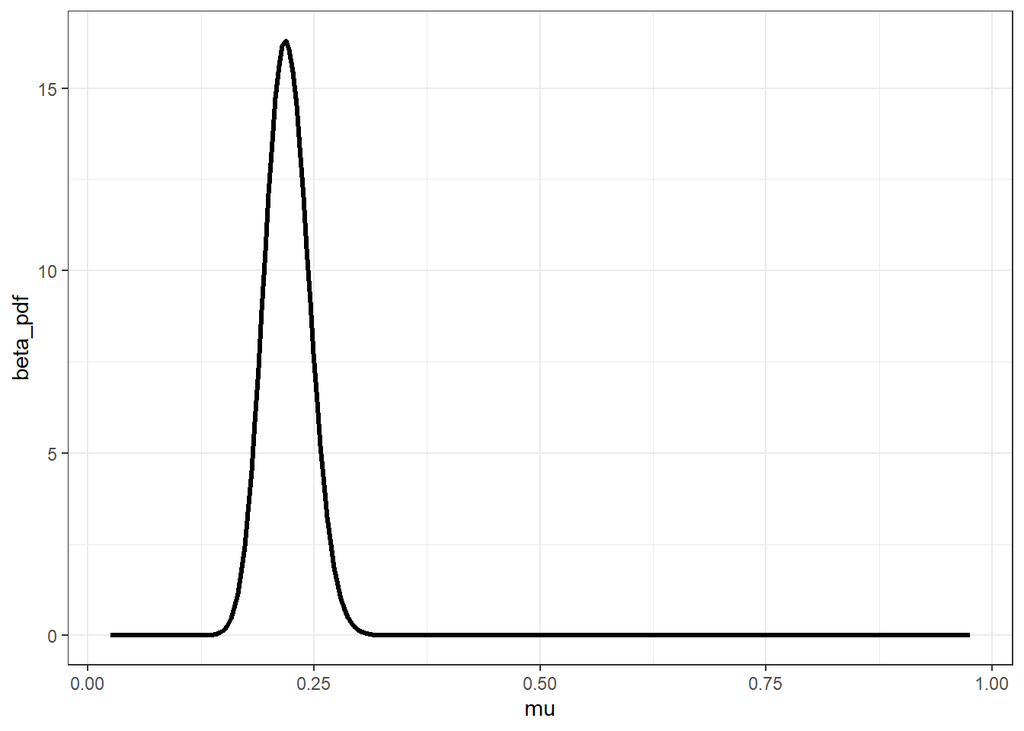

```r
tibble::tibble(
  mu = mu_grid
) %>%
  mutate(beta_pdf = dbeta(mu, shape1 = 63, shape2 = 223)) %>%
  ggplot(mapping = aes(x = mu, y = beta_pdf)) +
  geom_line(size = 1.1) +
  theme_bw()
```

The posterior distribution based on the larger sample size and the Informative prior is shown below.

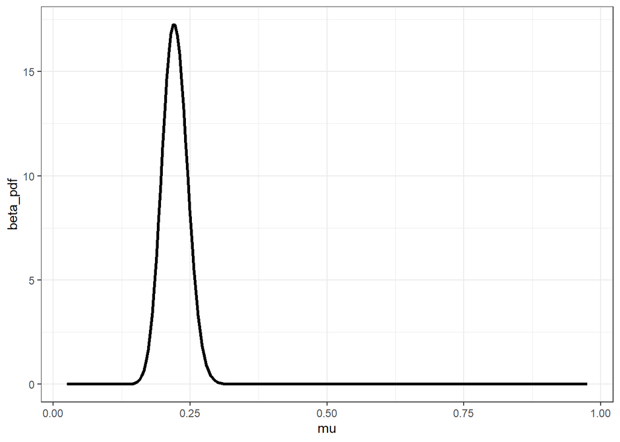

```r
tibble::tibble(
  mu = mu_grid
) %>%
  mutate(beta_pdf = dbeta(mu, shape1 = 72, shape2 = 252)) %>%
  ggplot(mapping = aes(x = mu, y = beta_pdf)) +
  geom_line(size = 1.1) +
  theme_bw()
```

That was all you were required to do to receive full credit for this problem. However, as was done in 6c), it can help to directly overlay the two posteriors on the same plot to confirm just how close they are to each other. The figure below uses `color` and `linetype` aesthetics to differentiate the posterior “coming from” the Uniform and Informative prior. The two distributions are so similar it is difficult to distinguish between them!

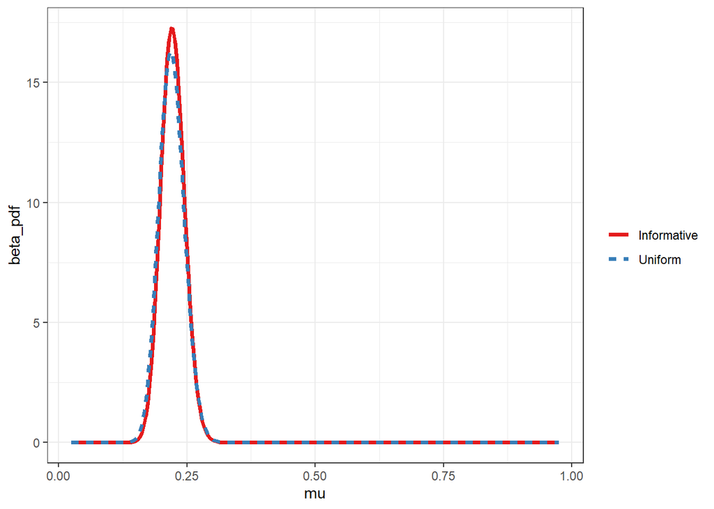

```r
tibble::tibble(
  mu = mu_grid
) %>%
  mutate(beta_pdf = dbeta(mu, shape1 = 63, shape2 = 223),
         from_prior = 'Uniform') %>%
  bind_rows(tibble::tibble(mu = mu_grid) %>%
              mutate(beta_pdf = dbeta(mu, shape1 = 72, shape2 = 252),
                     from_prior = 'Informative')) %>%
  ggplot(mapping = aes(x = mu, y = beta_pdf)) +
  geom_line(size = 1.25,
            mapping = aes(color = from_prior,
                          linetype = from_prior)) +
  scale_color_brewer('', palette = 'Set1') +
  scale_linetype_discrete('') +
  theme_bw()
```

### 7d)

You examined the sensitivity of the posterior to two types of prior assumptions based on two sample sizes. One prior is uniform, while the other is “informative”. One sample size was small, while the other was larger.

**Describe the influence of the prior on the posterior when the sample size is small vs large.**

#### SOLUTION

To receive full credit you needed to state something to the effect of: large sample sizes can overwhelm the prior! The posterior is not sensitive to the prior when the sample size is large! Essentially, our prior belief no longer matters when the sample size is large!

You did not need to make any plots for this question, but the code chunk below directly compares the four posterior distributions in this assignment. The two small sample size cases are compared to the large sample size cases. The colors are consistent with the previous figures, thus the red curves are the posteriors associated with the Informative prior and the blue curves are the posteriors associated with the Uniform prior. The sample size is denoted by the line type. The solid curves are the posteriors associated with the large sample size while the dashed curves are the posteriors associated with the sample sample size.

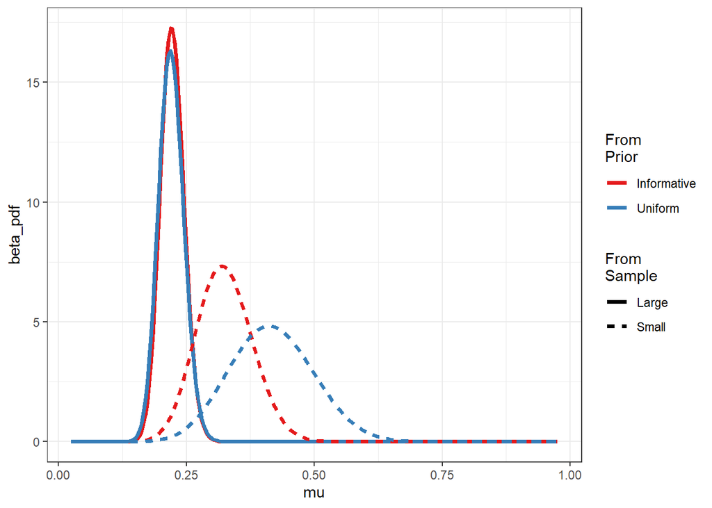

```r
tibble::tibble(
  mu = mu_grid
) %>%
  mutate(beta_pdf = dbeta(mu, shape1 = 15, shape2 = 21),
         from_prior = 'Uniform') %>%
  bind_rows(tibble::tibble(mu = mu_grid) %>%
              mutate(beta_pdf = dbeta(mu, shape1 = 24, shape2 = 50),
                     from_prior = 'Informative')) %>%
  mutate(from_sample = "Small") %>%
  bind_rows(tibble::tibble(
    mu = mu_grid
  ) %>%
    mutate(beta_pdf = dbeta(mu, shape1 = 63, shape2 = 223),
           from_prior = 'Uniform') %>%
    bind_rows(tibble::tibble(mu = mu_grid) %>%
                mutate(beta_pdf = dbeta(mu, shape1 = 72, shape2 = 252),
                       from_prior = 'Informative')) %>%
    mutate(from_sample = 'Large')) %>%
  ggplot(mapping = aes(x = mu, y = beta_pdf)) +
  geom_line(size = 1.25,
            mapping = aes(color = from_prior,
                          linetype = from_sample,
                          group = interaction(from_prior,
                                              from_sample))) +
  scale_color_brewer('From\nPrior', palette = 'Set1') +
  scale_linetype_discrete('From\nSample') +
  theme_bw()
```

We can reach the same conclusions if we visualize the posterior summary statistics instead of the distributions. The posterior 90% uncertainty intervals are displayed by the vertical lines and the posterior means are shown by the dots in the figure below. The posterior modes are not shown to simplify the figure. The `x` aesthetic denotes the sample size and the color denotes the prior.

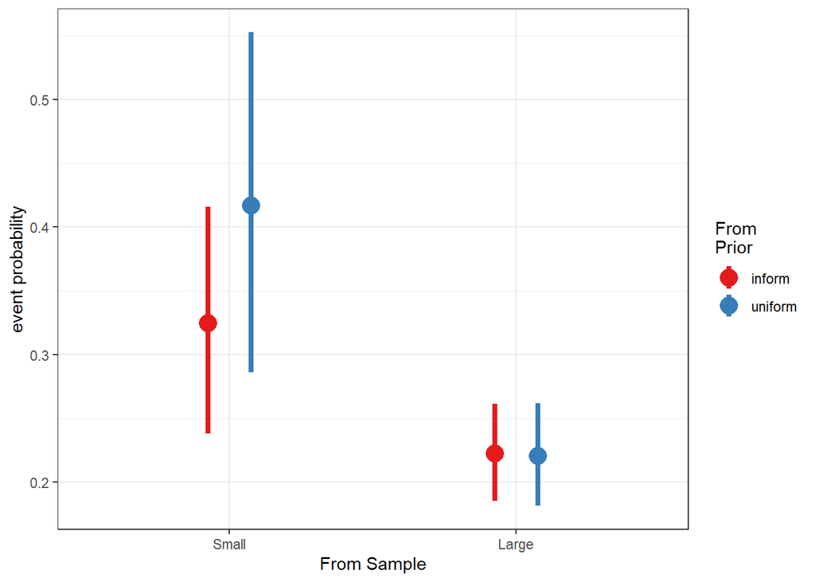

```r
season_results %>%
  mutate(post_mean = a_new /(a_new + b_new),
         post_mode = (a_new - 1) / (a_new + b_new - 2),
         post_q05 = qbeta(0.05, a_new, b_new),
         post_q95 = qbeta(0.95, a_new, b_new)) %>%
  mutate(from_sample = "Large") %>%
  bind_rows(post_results %>%
              mutate(post_mean = a_new /(a_new + b_new),
         post_mode = (a_new - 1) / (a_new + b_new - 2),
         post_q05 = qbeta(0.05, a_new, b_new),
         post_q95 = qbeta(0.95, a_new, b_new)) %>%
           mutate(from_sample = "Small")) %>%
  mutate(from_sample = forcats::fct_rev(from_sample)) %>%
  ggplot(mapping = aes(x = from_sample)) +
  geom_linerange(mapping = aes(ymin = post_q05,
                               ymax = post_q95,
                               group = interaction(from_sample, prior_type),
                               color = prior_type),
                 size = 1.5,
                 position = position_dodge(0.3)) +
  geom_point(mapping = aes(y = post_mean,
                           group = interaction(from_sample, prior_type),
                           color = prior_type),
             shape = 16, size = 5,
             position = position_dodge(0.3)) +
  scale_color_brewer('From\nPrior', palette = 'Set1') +
  labs(x = 'From Sample', y = 'event probability') +
  theme_bw()
```